# DataAnalysis - Postprocessing Results MaxQuant

19 Juli 2022, 13:22:02

# 1 Global Parameters

```r
###############################
#
#define settings
#
###############################

GET_SAMPLE_NAMES <- TRUE # if set to FALSE define it in the next line
#sample_names_user <- c()

unique <- 2  # how many peptides should be at least necessary to identify a protein

# which types should be evaluated TRUE or FALSE could be used
RAZOR <- TRUE
UNIQUE <- TRUE
LFQ <- TRUE

# define path of the proteinGroups.txt file(s)
path = "N:/1_A_Bachelor_Master_Intern/00_M_2022/David/Data/3_20220406_TR/20220406_TR_QC_MBR_rerun_4masterthesis/"
path = "N:/1_A_Bachelor_Master_Intern/00_M_2022/David/Data/10_20220712_TR/mqpar_20220712_extracts/"
# save files | options
# FALSE - results are not saved
# "RDS" - save results into R data file format
# "CSV" - save results into a csv file
SAVE <- "CSV"
```

# 2 Introduction

## 2.1 Unique | Razor&Unique procedure

Filtering:

- `Potential.contaminant != "+"` -> remove where contaminants
- `Reverse != "+"`-> remove where reverse = +
- `Only.identified.by.site != "+"` -> remove where only identified by site = +
- `data[name] >= unique` -> keep only identifications which have greater or equal number (defined via variable `unique`) of `razor/unique peptides` | typically this is set to 1 or 2

`Data analysis` show the number of identified proteins and the heatmap. In `Summary` the final results are visualized as boxplot and a table with the summarized values is shown.

## 2.2 LFQ-Procedure

Filtering:

- `Potential.contaminant != "+"` -> remove where contaminants = +
- `Reverse != "+"`-> remove where reverse = +
- `Only.identified.by.site != "+"` -> remove where only identified by site = +

Then the `log2`of the LFQ intensities is calculated and all `-Inf` values were substituted by NA using the following command: `lfq[lfq == -Inf] <- NA`

`Data analysis` show the number of identified proteins and the heatmap. In `Summary` the final results are visualized as boxplot and a table with the summarized values is shown.

# 3 Load required packages and functions

```r
# load libraries
library(tidyverse)
library(dplyr)
library(pheatmap)
library(ggplot2)
library(reshape)
library(knitr)
# load functions
filtering <- function(d){
  data_raw %>% filter(
    Potential.contaminant != "+",
    Reverse != "+",
    Only.identified.by.site != "+")
}
print("loading sucessful")
```

```
## [1] "loading sucessful"
```

# 4 Data Analysis

The txt-files of the defined folder are read in, processed and filtered automatically. This section shows the code, heatmaps for LFQ values and also some summary statistics.

```r
########## read in all data with pattern .txt
# get file list
file.list <- list.files(path = path, pattern='*.txt')
# create file path
file.path <- paste(path,file.list,sep = "")
# read in files - for each file one variable is created - results are stored in a list
res_raw <- lapply(file.path, read.delim)
names(res_raw) <- file.list

########## get sample names
if (GET_SAMPLE_NAMES == TRUE){
  #get sample names
  tmp <- colnames(res_raw[[1]])
  tmp <- tmp[grep("Razor...unique.peptides.",tmp)]
  tmp <- sub(".*Razor...unique.peptides.", "",tmp)
  sample_names_raw <- tmp
  rm(tmp)
  #create sample names
  sample_names_razor <- paste("Razor...unique.peptides.",sample_names_raw, sep="")
  sample_names_unique <- paste("Unique.peptides.",sample_names_raw, sep="")
  sample_names_lfq <- paste("LFQ.intensity.",sample_names_raw, sep="")
} else {
  for (i in 1:length(file.list)){
    # rename columns
    res_raw[[i]] <- res_raw[[i]] %>%
       rename_with(~ paste("Razor_", sample_names_user, sep = ""),
                   starts_with("Razor...unique.peptides.")) %>%
       rename_with(~ paste("Unique_", sample_names_user, sep = ""),
                   starts_with("Unique.peptides.")) %>%
       rename_with(~ paste("LFQ_", sample_names_user, sep = ""),
                   starts_with("LFQ.intensity."))
    # get column names
    sample_names_razor <- colnames(res_raw[[i]][grep("Razor_",
                                                colnames(res_raw[[i]]))])
    sample_names_unique <- colnames(res_raw[[i]][grep("Unique_",
                                                colnames(res_raw[[i]]))])
    sample_names_lfq <- colnames(res_raw[[i]][grep("LFQ_",
                                                 colnames(res_raw[[i]]))])
    }
}

########## create result data frame & result lists
# create data frame for razor
results_2gether_razor <- data.frame(matrix(ncol = length(sample_names_razor), nrow = length(file.list)))
row.names(results_2gether_razor) <- file.list
colnames(results_2gether_razor) <- sample_names_razor
#create data frame for unique
results_2gether_unique <- data.frame(matrix(ncol = length(sample_names_unique), nrow = length(file.list)))
row.names(results_2gether_unique) <- file.list
colnames(results_2gether_unique) <- sample_names_unique
#create data frame for lfq
results_2gether_lfq <- data.frame(matrix(ncol = length(sample_names_lfq), nrow = length(file.list)))
row.names(results_2gether_lfq) <- file.list
colnames(results_2gether_lfq) <- sample_names_lfq

#results lists
results_razor <- list()
results_unique <- list()
results_lfq <- list()

########## perform evaluation
if (RAZOR == TRUE) {
  cat("\n")
  cat("##","Razor","\n")
  cat("\n")
  for (x in file.list){
    cat("\n")
    cat("###",substring(x, 1, nchar(x)-4),"\n")
    data_raw <- as.data.frame(res_raw[[x]])
    data <- filtering(data_raw)
    results <- data.frame(matrix(ncol = length(sample_names_razor), nrow = nrow(data)))
    colnames(results) <- sample_names_razor
    i <- 0
    for (i in 1:length(sample_names_razor)){
      name <- sample_names_razor[i]
      tmp <- (data[name] >= unique)
      results[i] <- tmp
      cat(name,"<br/>",sum(tmp, na.rm = TRUE),"<br/>")
    }
    results_razor[[x]] <- results
    results_2gether_razor[x,] <- sapply(results,function(x)sum(x, na.rm = TRUE))
    cat("\n")

        #create heatmaps
    paletteLength <- 50
    myColor <- colorRampPalette(c("navy", "white",
                                  "firebrick3"))(paletteLength)
      data4pheatmap <- results
      data4pheatmap <- results
      data4pheatmap <- data4pheatmap*1
      data4pheatmap[data4pheatmap == 0] <- NA
      # remove NA rows
      ind <- apply(data4pheatmap, 1, function(x) all(is.na(x)))
      data4pheatmap_clear <- data4pheatmap[!ind,]
      data4pheatmap_clear[is.na(data4pheatmap_clear)] <- 0
      if (ncol(data4pheatmap_clear) < 2){
        cat("\n")
        cat("##"," No heatmap possible. Too less columns in the result
            table.","\n")
      } else {
        pheatmap(data4pheatmap_clear,
           color = myColor,
           treeheight_row = 10,
           angle_col ="45",
           treeheight_col = 10,
           legend = TRUE,
           labels_row = rep("",nrow(data4pheatmap)),
           labels_col = sample_names_raw)
        cat("\n")
      }
  }
}
```

## 4.1 Razor

### 4.1.1 proteinGroups

Razor…unique.peptides.D2_2_gesamt  
605  
Razor…unique.peptides.D2_3_gesamt  
645

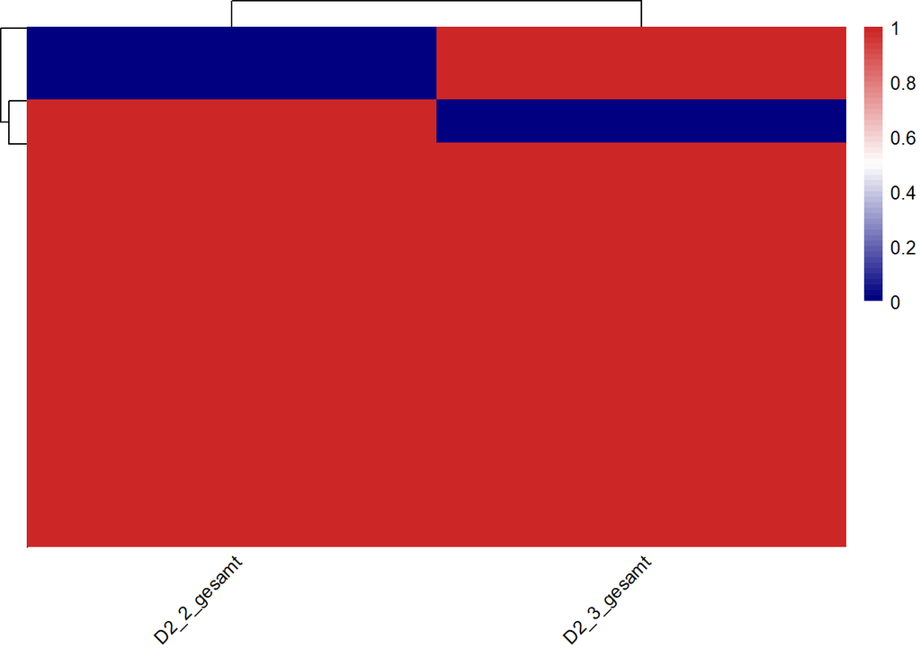

```r
if (UNIQUE == TRUE) {
  cat("\n")
  cat("##","Unique","\n")
  cat("\n")
  for (x in file.list){
    cat("\n")
    cat("###",substring(x, 1, nchar(x)-4),"\n")
    data_raw <- as.data.frame(res_raw[[x]])
    data <- filtering(data_raw)
    results <- data.frame(matrix(ncol = length(sample_names_unique), nrow = nrow(data)))
    colnames(results) <- sample_names_unique
    i <- 0
    for (i in 1:length(sample_names_unique)){
      name <- sample_names_unique[i]
      tmp <- (data[name] >= unique)
      results[i] <- tmp
      cat(name,"<br/>",sum(tmp, na.rm = TRUE),"<br/>")
    }
    results_unique[[x]] <- results
    results_2gether_unique[x,] <- sapply(results,function(x)sum(x, na.rm = TRUE))
    cat("\n")
    #create heatmaps
    paletteLength <- 50
    myColor <- colorRampPalette(c("navy", "white",
                                  "firebrick3"))(paletteLength)
      data4pheatmap <- results
      data4pheatmap <- data4pheatmap*1
      data4pheatmap[data4pheatmap == 0] <- NA
      # remove NA rows
      ind <- apply(data4pheatmap, 1, function(x) all(is.na(x)))
      data4pheatmap_clear <- data4pheatmap[!ind,]
      data4pheatmap_clear[is.na(data4pheatmap_clear)] <- 0
      if (ncol(data4pheatmap) < 2){
        cat("\n")
        cat("##"," No heatmap possible. Too less columns in the result
            table.","\n")
      } else {
        pheatmap(data4pheatmap_clear,
           color = myColor,
           treeheight_row = 10,
           angle_col ="45",
           treeheight_col = 10,
           legend = TRUE,
           labels_row = rep("",nrow(data4pheatmap)),
           labels_col = sample_names_raw)
        cat("\n")
      }
  }
}
```

## 4.2 Unique

### 4.2.1 proteinGroups

Unique.peptides.D2_2_gesamt  
599  
Unique.peptides.D2_3_gesamt  
640

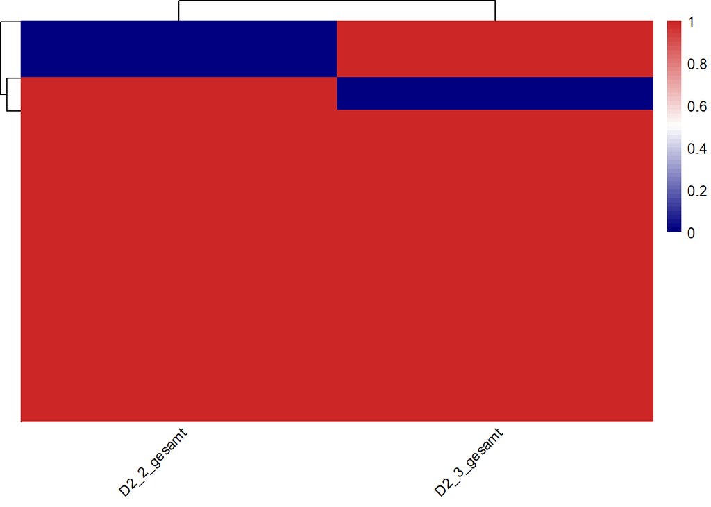

```r
if (LFQ == TRUE) {
  cat("\n")
  cat("##","LFQ","\n")
  cat("\n")
  for (x in file.list){
    cat("\n")
    cat("###",substring(x, 1, nchar(x)-4),"\n")
    data_raw <- as.data.frame(res_raw[[x]])
    data <- filtering(data_raw)

    results <- data.frame(matrix(ncol = length(sample_names_lfq), nrow = nrow(data)))
    colnames(results) <- sample_names_lfq
    i <- 0
    for (i in 1:length(sample_names_lfq)){
      name <- sample_names_lfq[i]
      tmp <- log2(data[name])
      tmp[tmp == -Inf] <- NA
      results[i] <- tmp
      cat(name,"<br/>",sum(!is.na(tmp)),"<br/>")

    }

    results_lfq[[x]] <- results
    results_2gether_lfq[x,] <- sapply(results,function(x)sum(!is.na(x)))
    cat("\n")

    #create heatmaps
    paletteLength <- 50
    myColor <- colorRampPalette(c("navy", "white",
                                  "firebrick3"))(paletteLength)
      data4pheatmap <- results
      data4pheatmap <- results
      data4pheatmap <- data4pheatmap*1
      data4pheatmap[data4pheatmap == 0] <- NA
      # remove NA rows
      ind <- apply(data4pheatmap, 1, function(x) all(is.na(x)))
      data4pheatmap_clear <- data4pheatmap[!ind,]
      data4pheatmap_clear[is.na(data4pheatmap_clear)] <- 0
      if (ncol(data4pheatmap) < 2){
        cat("\n")
        cat("##"," No heatmap possible. Too less columns in the result
            table.","\n")
      } else {
        pheatmap(data4pheatmap_clear,
           color = myColor,
           treeheight_row = 10,
           angle_col ="45",
           treeheight_col = 10,
           legend = TRUE,
           labels_row = rep("",nrow(data4pheatmap)),
           labels_col = sample_names_raw)
        cat("\n")
      }
  }
}
```

## 4.3 LFQ

### 4.3.1 proteinGroups

LFQ.intensity.D2_2_gesamt  
466  
LFQ.intensity.D2_3_gesamt  
466

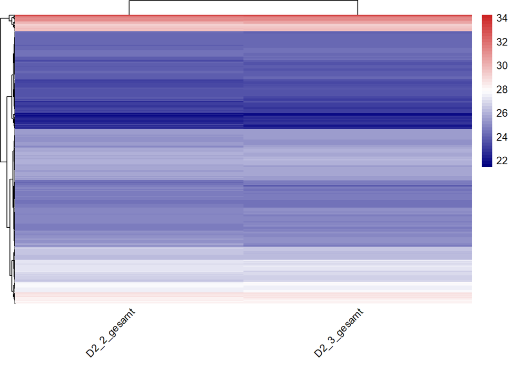

# 5 Summary

```r
# show summary
if (RAZOR == TRUE){
  cat("\n")
  cat("##"," Summary Razor","\n")
  print(kable(results_2gether_razor))

  ggplot(melt(results_2gether_razor),aes(x = variable, y = value)) +
  geom_boxplot() +
  xlab("Sample name") +
  scale_x_discrete(labels = sample_names_raw) +
  theme(axis.text.x = element_text(angle = 90)) +
  labs(title = "Razor")
}
```

## 5.1 Summary Razor

|  | Razor…unique.peptides.D2_2_gesamt | Razor…unique.peptides.D2_3_gesamt |
| --- | --- | --- |
| proteinGroups.txt | 605 | 645 |

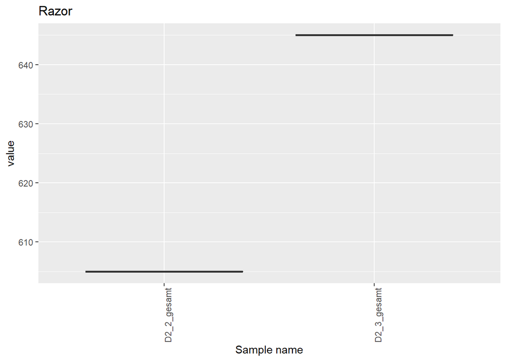

```r
if (UNIQUE == TRUE){
  cat("\n")
  cat("##"," Summary Unique","\n")
  print(kable(results_2gether_unique))

  ggplot(melt(results_2gether_unique),aes(x = variable, y = value)) +
  geom_boxplot() +
  xlab("Sample name") +
  scale_x_discrete(labels = sample_names_raw) +
  theme(axis.text.x = element_text(angle = 90)) +
  labs(title = "Unique")
}
```

## 5.2 Summary Unique

|  | Unique.peptides.D2_2_gesamt | Unique.peptides.D2_3_gesamt |
| --- | --- | --- |
| proteinGroups.txt | 599 | 640 |

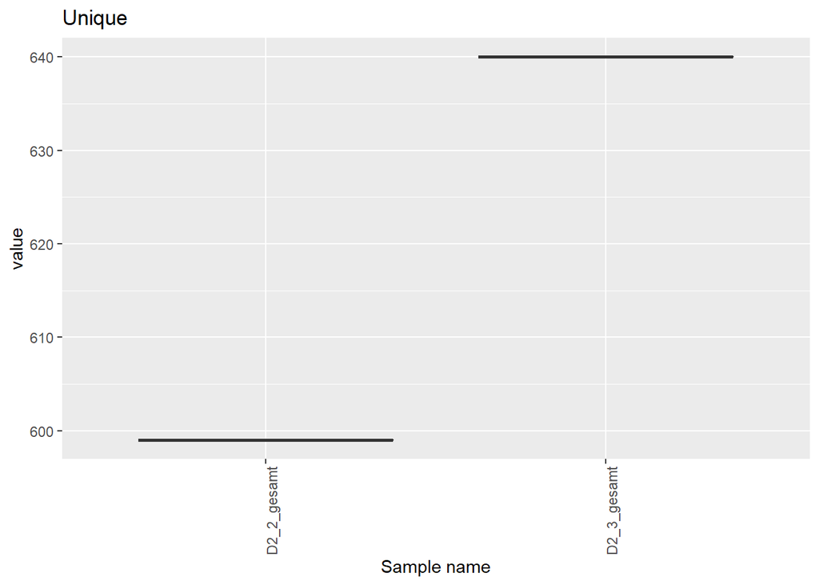

```r
if (LFQ == TRUE){
  cat("\n")
  cat("##"," Summary LFQ","\n")
  print(kable(results_2gether_lfq))

  ggplot(melt(results_2gether_lfq),aes(x = variable, y = value)) +
  geom_boxplot() +
  xlab("Sample name") +
  scale_x_discrete(labels = sample_names_raw) +
  theme(axis.text.x = element_text(angle = 90)) +
  labs(title = "LFQ")
}
```

## 5.3 Summary LFQ

|  | LFQ.intensity.D2_2_gesamt | LFQ.intensity.D2_3_gesamt |
| --- | --- | --- |
| proteinGroups.txt | 466 | 466 |

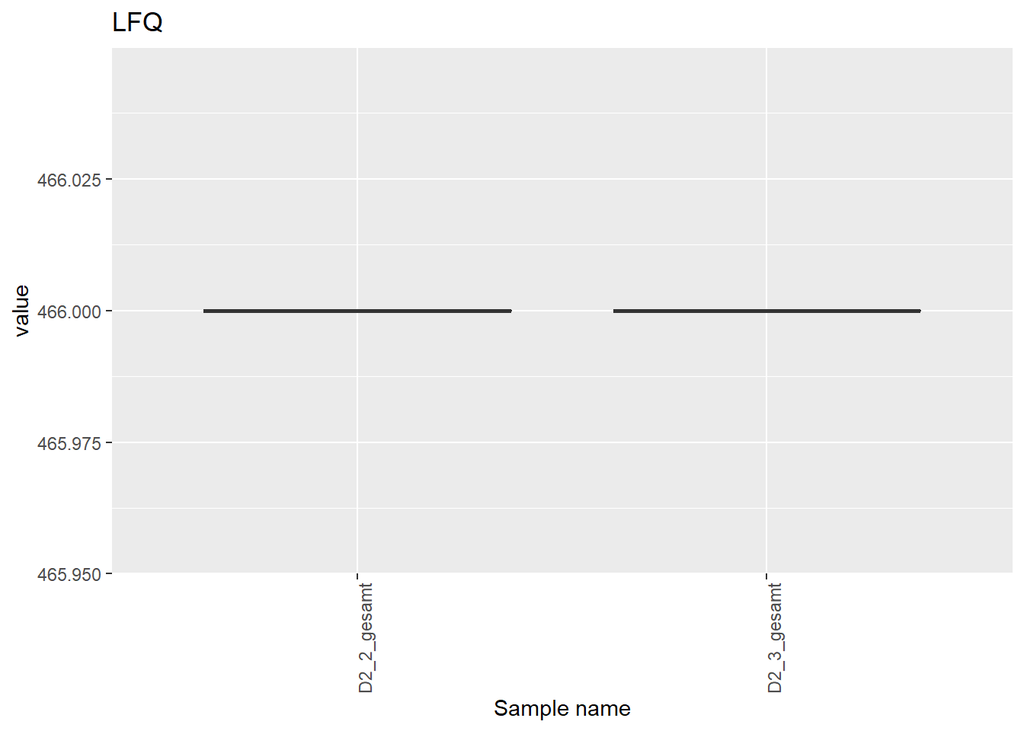

```r
# save results
results_final <- data.frame(results_2gether_razor,results_2gether_unique,results_2gether_lfq)
# get rid of NA columns
results_final <- results_final[,colSums(is.na(results_final))<nrow(results_final)]
if (SAVE == "RDS"){
  saveRDS(results_final, "./results_final.RDS")
} else if (SAVE == "CSV") {
  write.csv2(results_final, "./results_final.csv")
}
```

# 6 Used time

```
## [1] "Time used for analysis: 0.07 minutes"
```